# Web-Mining: a Kaggle competition

Beydia Mohamed Lemine

29 March 2018

The remainder of this Notebook is structured as follows. We will start by setting our work Environment. Then, we will download and import the data sets ; followed by a basic statistical analysis . Then we will go deeper by performing a graph analysis, a text mining analysis and features extractions from these both analysis. Finally, we perform a machine learning modeling using python as It is much faster than R.

Note that the first part of this Notebook, which corresponds to pre-processing and analysis, is performed with the software R.

## I ENVIRONEMENT’s PREPARATION

We are going to start by preparing our work environment. First of all we will create a folder “*data*” in which we are are going to store the data then we will install all the packages that will be needed and to avoid package version issues,we will check that these packages were not installed before.

```r
# I create my folder
setwd("C:/Users/mlemi/Desktop/kaggle/Webmining/notebook")
if (!file.exists("data")) {
    dir.create("data")
}
setwd("C:/Users/mlemi/Desktop/kaggle/Webmining/notebook/data")

# I put all the packages that will be required in a vector
packages <- c("devtools", "tidyr", "urltools", "stringr", "plyr", "readr", "data.table",
    "tm", "networkD3", "SnowballC", "Matrix", "lda", "LDAvis", "servr", "RCurl",
    "dplyr", "ggplot2")


# I check if theses packages are installed yet
diffp <- setdiff(packages, rownames(installed.packages()))
# if yes i do nothing if no i install them
if (length(diffp) > 0) {
    install.packages(diffp)
}
```

## II DATA IMPORTATION

```r
# I Set data urls
loginurl = "https://www.kaggle.com/account/login"
fileUrl_train_info <- "https://www.kaggle.com/c/recipient-prediction/download/training_info_sid.csv"
fileUrl_train_set <- "https://www.kaggle.com/c/recipient-prediction/download/training_set_sid.csv"
fileUrl_test_info <- "https://www.kaggle.com/c/recipient-prediction/download/test_info_sid.csv"
fileUrl_test_set <- "https://www.kaggle.com/c/recipient-prediction/download/test_set_sid.csv"
all_files <- list(fileUrl_train_info, fileUrl_train_set, fileUrl_test_info,
    fileUrl_test_set)


library(RCurl)
# Set user account data and agent
pars = list(UserName = "m.beydia@gmail.com", Password = "mohamed99")
agent = "Mozilla/5.0"  #or whatever

# Set RCurl pars
curl = getCurlHandle()
curlSetOpt(cookiejar = "cookies.txt", useragent = agent, followlocation = TRUE,
    curl = curl)


# Post login form
welcome = postForm(loginurl, .params = pars, curl = curl)

bdown = function(url, file, curl) {
    f = CFILE(file, mode = "wb")
    curlPerform(url = url, writedata = f@ref, noprogress = FALSE, curl = curl)
    close(f)
}

ret = lapply(1:4, function(i) {
    bdown(all_files[[i]], substring(all_files[[i]], 56), curl)
})

rm(curl)
gc()
```

Once the data downloaded, we load them the R console.

```r
# set my directory
setwd("C:/Users/mlemi/Desktop/kaggle/Webmining/notebook")

# Import the datasets
train_info <- read.csv("data/training_info_sid.csv", header = F)
train_set <- read.csv("data/training_set_sid.csv", header = F)

test_info <- read.csv("data/test_info_sid.csv", header = F)
test_set <- read.csv("data/test_set_sid.csv", header = F)
```

## III DATA PREPARATION

In this section, we are going to restructure our data sets in order to have one train data set and one test data set. Each row of theses data sets will contain one mail and one sender.

```r
### TRAIN ####

# I put names to the variables
names(train_info)<-c("Mail_ID","Date","Content","Recipients")
names(train_set)<-c("Sender","Mail_ID")

# This function will allow me to reshape the train_set and test_set
# The idea is to have, for each row, one mail and one sender
my_funct<-function(i,df){
  subdf=subset(df,rownames(df)==i)
  Sender_list=strsplit(as.character(subdf$Mail_ID)," ")
  Mail_ID=as.numeric(unlist(Sender_list))
  Sender=subdf$Sender
  mydf=cbind.data.frame(Sender,Mail_ID)
  return(mydf)
}


require(plyr)
# I apply the function to the row of the train_set
mydf = ldply(1:dim(train_set)[1], my_funct, df=train_set, .progress = 'text')

# At the end I merge the previous output with the train_info set to get a complete data set
Training<-join(mydf, train_info,type = "left")

# I rearenge order of dataset
Training<-Training[,c(2,1,3:5)]

### Test ####

# I reapeat the same preprocessing to the test dataset
names(test_info)<-c("Mail_ID","Date","Content")
names(test_set)<-c("Sender","Mail_ID")

mydftest=ldply(1:dim(test_set)[1], my_funct, df=test_set, .progress = 'text')

Test<-join(mydftest, test_info,type = "left")
# rearenge order of dataset
Test<-Test[,c(2,1,3:4)]
```

Visualize what a I have done so far : I choose do display these row precisely just for illustration sake since the content is not to big

```r
writeLines("td, th { padding : 6px } th { background-color : brown ; color : white; border : 1px solid white; } td { color : brown ; border : 1px solid brown }", con = "mystyle.css")
knitr::kable(Training[18:19,], format = "html")
```

|  | Mail_ID | Sender | Date | Content | Recipients |
| --- | --- | --- | --- | --- | --- |
| 18 | 4200 | strobe.talbott@univ-tlse3.fr | 2010-01-18T05:00:00+00:00 | UNCLASSIFIED U.S. D | hillary.clinton@univ-tlse3.fr |
| 19 | 4201 | strobe.talbott@univ-tlse3.fr | 2010-01-18T05:00:00+00:00 | At airport, flying to LA. Landing around 3 p.m. Available for a few minutes now onCan you talk/meet today?UNCLASSIFIED U.S. D | hillary.clinton@univ-tlse3.fr |

```r
writeLines("td, th { padding : 6px } th { background-color : brown ; color : white; border : 1px solid white; } td { color : brown ; border : 1px solid brown }", con = "mystyle.css")
knitr::kable(Test[16:18,], format = "html")
```

|  | Mail_ID | Sender | Date | Content |
| --- | --- | --- | --- | --- |
| 16 | 1940 | sidney.blumenthal@univ-tlse3.fr | 2009-06-23T04:00:00+00:00 | A Good Credit Score is 700 or Above. See yours in just 2 easy steps! |
| 17 | 2069 | sidney.blumenthal@univ-tlse3.fr | 2009-07-09T04:00:00+00:00 | Re: The drift |
| 18 | 2075 | sidney.blumenthal@univ-tlse3.fr | 2009-06-12T04:00:00+00:00 | Shop Dell’s full line of Laptops now starting at $349! |

## IV BASIC ANALYSIS

Let’s start by counting how many how many emails has been sent or received per person.

But before that we will Reshape the training data set in order to have for each mail , one recipient

```r
# The following function will help us to have have one recipient per mail sent
my_funct2<-function(i,df){
  subdf=subset(df,Mail_ID==i)
  recipients_list=strsplit(as.character(subdf$Recipients)," ")
  recipient=(unlist(recipients_list))
  mydftest=cbind.data.frame(subdf[1:4],recipient)
  return(mydftest)
}

invisible(suppressWarnings((Trainingv2 = ldply(min(Training$Mail_ID):max(Training$Mail_ID), my_funct2,df=Training))))
```

display what I have done so Fare

```r
writeLines("td, th { padding : 6px } th { background-color : brown ; color : white; border : 1px solid white; } td { color : brown ; border : 1px solid brown }", con = "mystyle.css")
knitr::kable(Trainingv2[1:3,], format = "html")
```

| Mail_ID | Sender | Date | Content | recipient |
| --- | --- | --- | --- | --- |
| 1 | jake.sullivan@univ-tlse3.fr | 2012-09-12T04:00:00+00:00 | What a wonderful, strong and moving statement by your boss. please tell her how much Sen. McCain appreciated it. Me too | hillary.clinton@univ-tlse3.fr |
| 3 | cheryl.mills@univ-tlse3.fr | 2012-09-12T04:00:00+00:00 | ThxTo you and all my former colleagues, I’m so terribly sorry. Our FSOs stand on the front lines just as surely and devotedly as our soldiers do. Thinking of you and Pat and everyone this morning. AM | b6@univ-tlse3.fr |
| 3 | cheryl.mills@univ-tlse3.fr | 2012-09-12T04:00:00+00:00 | ThxTo you and all my former colleagues, I’m so terribly sorry. Our FSOs stand on the front lines just as surely and devotedly as our soldiers do. Thinking of you and Pat and everyone this morning. AM | hillary.clinton@univ-tlse3.fr |

As you can see I have one recipient per row

Now Lets start plotting : Received Mails

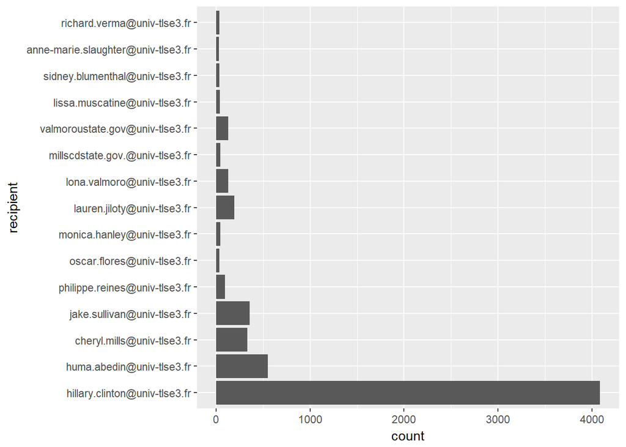

```r
library(dplyr)
# firts I summarize the Training data by grouping the emails sent by
# recipient
email_recevied_count = Trainingv2 %>% dplyr::group_by(recipient) %>% dplyr::summarize(count = n())
# reorder the created dataset
email_recevied_count <- as.data.frame(email_recevied_count)[order(-email_recevied_count$count),
    ]
# make a Barplot with ggplot
library(ggplot2)

p <- ggplot(data = email_recevied_count[1:15, ], aes(x = recipient, y = count)) +
    geom_bar(stat = "identity") + scale_x_discrete(limits = email_recevied_count[1:15,
    ]$Sender)
p + coord_flip()
```

second plot : Mails sent

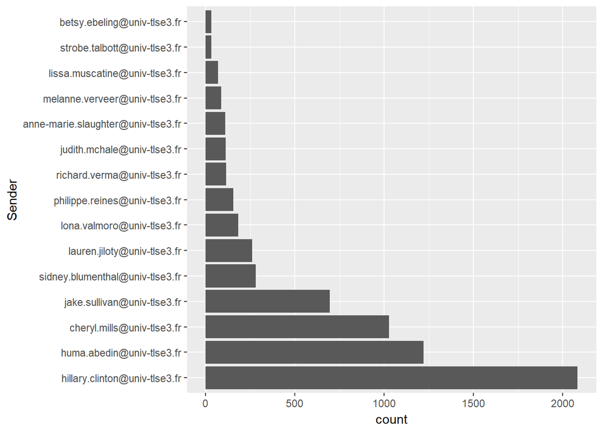

```r
# firts I summarize the Training data by grouping the emails sent by sender
email_sent_count = Trainingv2 %>% dplyr::group_by(Sender) %>% dplyr::summarize(count = n())
# order the created dataset
email_sent_count <- as.data.frame(email_sent_count)[order(-email_sent_count$count),
    ]
# make a Barplot
p <- ggplot(data = email_sent_count[1:15, ], aes(x = Sender, y = count)) + geom_bar(stat = "identity") +
    scale_x_discrete(limits = email_sent_count[1:15, ]$Sender)
p + coord_flip()
```

We have seen the Hillary seems the one who send and receive the most emails , which make sense :) Now Let’s make a prediction based only on frequencies to see what will it score

```r
Top10_receivers <- list(as.character(email_recevied_count[1:10, ]$recipient))

rv = character()  # Initialize an empty vector
for (i in 1:10) {
    rv = paste(rv, unlist(Top10_receivers)[i])
}  # in the previous vector, we put the top 10 mail_adresses for each row

pred_freq <- as.data.frame(cbind(Test$Mail_ID, rv))  # create a final dataframe in which i merge the mail ids and the top_mail
names(pred_freq) <- c("Id", "Recipients")  # rename the headers
# export the dataframe into a csv file (needed format for kaggle)
write.csv2(pred_freq, file = "topfreq_submission.csv", row.names = F)
```

## V NETWORK ANALYSIS

In this section we will make some network(graph) analysis

```r
emailInteractionsLinks = Trainingv2 %>% dplyr::group_by(Sender, recipient) %>%
    dplyr::summarize(count = n())

# let's consider only the case we have more than one interaction
emailInteractionsLinks = emailInteractionsLinks[emailInteractionsLinks$count >
    1, ]
# initialize target and source
emailInteractionsLinks$source = -1
emailInteractionsLinks$target = -1

emailInteractionsLinks$Sender <- as.character(emailInteractionsLinks$Sender)
emailInteractionsLinks$recipient <- as.character(emailInteractionsLinks$recipient)

uniqueInteractionPersons = unique(c(emailInteractionsLinks$Sender, emailInteractionsLinks$recipient))
emailInteractionsNodes <- data.frame(name = uniqueInteractionPersons, stringsAsFactors = FALSE)
emailInteractionsNodes$group = 0
emailInteractionsNodes$size = 0
```

display what I have done so Fare

```r
head(emailInteractionsLinks[1:5, ])
```

```
## # A tibble: 5 x 5
## # Groups:   Sender [3]
##   Sender                             recipient         count source target
##   <chr>                              <chr>             <int>  <dbl>  <dbl>
## 1 alcb@univ-tlse3.fr                 hillary.clinton@~     4  -1.00  -1.00
## 2 andrew.shapiro@univ-tlse3.fr       hillary.clinton@~     3  -1.00  -1.00
## 3 anne-marie.slaughter@univ-tlse3.fr hillary.clinton@~    96  -1.00  -1.00
## 4 anne-marie.slaughter@univ-tlse3.fr cheryl.mills@uni~     2  -1.00  -1.00
## 5 anne-marie.slaughter@univ-tlse3.fr jake.sullivan@un~     3  -1.00  -1.00
```

```r
head(emailInteractionsNodes[1:5, ])
```

```
##                                 name group size
## 1                 alcb@univ-tlse3.fr     0    0
## 2       andrew.shapiro@univ-tlse3.fr     0    0
## 3 anne-marie.slaughter@univ-tlse3.fr     0    0
## 4    arturo.valenzuela@univ-tlse3.fr     0    0
## 5     barbara.mikulski@univ-tlse3.fr     0    0
```

```r
for (i in 1:nrow(emailInteractionsLinks)) {
    senderIndex = match(emailInteractionsLinks[i, "Sender"], emailInteractionsNodes$name)
    recipientIndex = match(emailInteractionsLinks[i, "recipient"], emailInteractionsNodes$name)

    emailInteractionsLinks[i, ]$source = senderIndex - 1
    emailInteractionsLinks[i, ]$target = recipientIndex - 1

    emailInteractionsNodes[senderIndex, ]$size = emailInteractionsNodes[senderIndex,
        ]$size + emailInteractionsLinks[i, ]$count

    emailInteractionsNodes[recipientIndex, ]$size = emailInteractionsNodes[recipientIndex,
        ]$size + emailInteractionsLinks[i, ]$count
}

emailInteractionsNodes$group = round(log2(emailInteractionsNodes$size + 1))
emailInteractionsNodes$size = round(sqrt(emailInteractionsNodes$size))

# display what I have done so Fare
head(emailInteractionsLinks[1:5, ])
```

```
## # A tibble: 5 x 5
## # Groups:   Sender [3]
##   Sender                             recipient         count source target
##   <chr>                              <chr>             <int>  <dbl>  <dbl>
## 1 alcb@univ-tlse3.fr                 hillary.clinton@~     4   0      23.0
## 2 andrew.shapiro@univ-tlse3.fr       hillary.clinton@~     3   1.00   23.0
## 3 anne-marie.slaughter@univ-tlse3.fr hillary.clinton@~    96   2.00   23.0
## 4 anne-marie.slaughter@univ-tlse3.fr cheryl.mills@uni~     2   2.00   11.0
## 5 anne-marie.slaughter@univ-tlse3.fr jake.sullivan@un~     3   2.00   27.0
```

```r
head(emailInteractionsNodes[1:5, ])
```

```
##                                 name group size
## 1                 alcb@univ-tlse3.fr     2    2
## 2       andrew.shapiro@univ-tlse3.fr     3    3
## 3 anne-marie.slaughter@univ-tlse3.fr     7   11
## 4    arturo.valenzuela@univ-tlse3.fr     3    2
## 5     barbara.mikulski@univ-tlse3.fr     4    3
```

Now lets visualize the network

```r
library(networkD3)

network <- forceNetwork(Links = as.data.frame(emailInteractionsLinks), Nodes = emailInteractionsNodes,
    Source = "source", Target = "target", Value = "count", NodeID = "name",
    Group = "group", width = 800, height = 600, fontSize = 10, Nodesize = "size",
    opacity = 0.9, zoom = TRUE)
network
```

[interactive chart not shown]

Now lets detect communities in our network. To do that we need to switch to another graph package and create again the network.

[figure not shown]

```r
suppressWarnings(library(igraph))
net <- graph_from_data_frame(d = emailInteractionsLinks, vertices = emailInteractionsNodes,
    directed = T)
net <- simplify(net, remove.multiple = F, remove.loops = T)

net.sym <- as.undirected(net, mode = "collapse", edge.attr.comb = list(weight = "sum",
    "ignore"))


# community clustering : fast greedy algorithm
cfg <- cluster_fast_greedy(as.undirected(net))
dendPlot(cfg, mode = "hclust")
```

```r
com_members <- membership(cfg)

community <- as.data.frame(cbind(V(net)$name, cfg$membership))
names(community) <- c("Sender", "Community_grp")
```

The communities were created , we see on the dendograme how many communities we have . Now lets have a look on whats is inside our communities .

```r
writeLines("td, th { padding : 6px } th { background-color : brown ; color : white; border : 1px solid white; } td { color : brown ; border : 1px solid brown }",
    con = "mystyle.css")
knitr::kable(head(community), format = "html")
```

| Sender | Community_grp |
| --- | --- |
| alcb@univ-tlse3.fr | 3 |
| andrew.shapiro@univ-tlse3.fr | 3 |
| anne-marie.slaughter@univ-tlse3.fr | 1 |
| arturo.valenzuela@univ-tlse3.fr | 3 |
| barbara.mikulski@univ-tlse3.fr | 3 |
| betsy.ebeling@univ-tlse3.fr | 5 |

what I found interesting is I get quite good groups like the group 6 in which we found only Hilary’s family : Chelsea , bill and a common mail dress (I guess) to Hillary and bill . This encouraged my to keep this result and to not use other community detection algorithms.

```r
writeLines("td, th { padding : 6px } th { background-color : brown ; color : white; border : 1px solid white; } td { color : brown ; border : 1px solid brown }",
    con = "mystyle.css")
knitr::kable(community[which(community$Community_grp %in% 6), ], format = "html")
```

|  | Sender | Community_grp |
| --- | --- | --- |
| 10 | chelsea.clinton@univ-tlse3.fr | 6 |
| 69 | bill.clinton@univ-tlse3.fr | 6 |
| 70 | dad.mom@univ-tlse3.fr | 6 |

```r
# I add the community feature to my datasets
library(plyr)
Trainingv3 <- join(Trainingv2, community, type = "left")
Testv3 <- join(Test, community, type = "left")
```

## VI TEXT MINING

### Pre-processing

Let’s do some pre-processing on the mail content .

```r
# Train dataset
Trainingv3$Content <- as.character(Trainingv3$Content)
Trainingv3$Content <- gsub("'", "", Trainingv3$Content)  # remove apostrophes
Trainingv3$Content <- gsub("[[:punct:]]", " ", Trainingv3$Content)  # replace punctuation with space
Trainingv3$Content <- gsub("[[:cntrl:]]", " ", Trainingv3$Content)  # replace control characters with space
Trainingv3$Content <- gsub("^[[:space:]]+", "", Trainingv3$Content)  # remove whitespace at beginning of documents
Trainingv3$Content <- gsub("[[:space:]]+$", "", Trainingv3$Content)  # remove whitespace at end of documents
Trainingv3$Content <- tolower(Trainingv3$Content)  # force to lowercase
# Test dataset
Testv3$Content <- as.character(Testv3$Content)
Testv3$Content <- gsub("'", "", Testv3$Content)  # remove apostrophes
Testv3$Content <- gsub("[[:punct:]]", " ", Testv3$Content)  # replace punctuation with space
Testv3$Content <- gsub("[[:cntrl:]]", " ", Testv3$Content)  # replace control characters with space
Testv3$Content <- gsub("^[[:space:]]+", "", Testv3$Content)  # remove whitespace at beginning of documents
Testv3$Content <- gsub("[[:space:]]+$", "", Testv3$Content)  # remove whitespace at end of documents
Testv3$Content <- tolower(Testv3$Content)  # force to lowercase
```

### Topic extraction

Now let’s extract the topics from the content of each mail. We will use this later as a feature in our model.

```r
## Source topicmodels2LDAvis & optimal_k functions
if (!require("pacman")) install.packages("pacman")
pacman::p_load_gh("trinker/gofastr")
pacman::p_load(tm, topicmodels, dplyr, tidyr, igraph, devtools, LDAvis, ggplot2)

## Source topicmodels2LDAvis & optimal_k functions
invisible(lapply(file.path("https://raw.githubusercontent.com/trinker/topicmodels_learning/master/functions",
    c("topicmodels2LDAvis.R", "optimal_k.R")), devtools::source_url))
```

```
## SHA-1 hash of file is 5ac52af21ce36dfe8f529b4fe77568ced9307cf0
```

```
## SHA-1 hash of file is 7f0ab64a94948c8b60ba29dddf799e3f6c423435
```

```r
########## generate stopwords ##########
stops <- c(tm::stopwords("english"), tm::stopwords("SMART")) %>% gofastr::prep_stopwords()

########## Create the DocumentTermMatrix ##########
Trainingv3$Content <- as.character(Trainingv3$Content)
Testv3$Content <- as.character(Testv3$Content)


mail_body <- Corpus(VectorSource(Trainingv3$Content))
dtm <- DocumentTermMatrix(mail_body)


doc_term_mat <- dtm %>% gofastr::remove_stopwords(stops, stem = TRUE) %>% gofastr::filter_tf_idf() %>%
    gofastr::filter_documents()

############## CONTROl LIST ################

control <- list(burnin = 500, iter = 1000, keep = 100, seed = 2500)
```

```r
############## Dertmine optimal number of topics ################

(k <- optimal_k(doc_term_mat, 50, control = control))
```

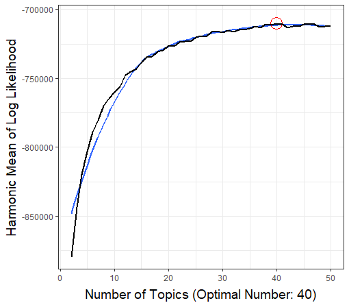

```r
############## Run the model ################

control[["seed"]] <- 100
lda_model <- topicmodels::LDA(doc_term_mat, k = as.numeric(k), method = "Gibbs",
    control = control)
```

```r
######################### get the topic #########################

topics <- topicmodels::posterior(lda_model, doc_term_mat)[["topics"]]
topic_dat <- dplyr::add_rownames(as.data.frame(topics), "Mail")
colnames(topic_dat)[-1] <- apply(terms(lda_model, 10), 2, paste, collapse = ", ")
```

```r
##################### Nice visualization ###########################

lda_model %>% topicmodels2LDAvis() %>% LDAvis::serVis()
```

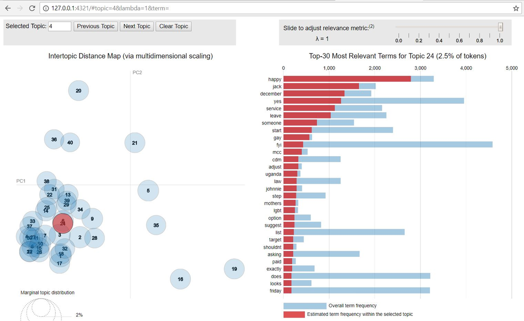

As you can, the output is a webpage on the localhost that allows to see what are the main frequent words by topics. Note also that we have a slider that allows us to change the value of relevant metrics :

### appending the most likly topic to my train dataset

Let’s have a look at the content of our topic extraction .

```r
### appending the most likly topic to my train dataset

library(data.table)
topic_dat <- as.data.table(topic_dat)


writeLines("td, th { padding : 6px } th { background-color : brown ; color : white; border : 1px solid white; } td { color : brown ; border : 1px solid brown }",
    con = "mystyle.css")
knitr::kable(head(topic_dat), format = "html")
```

| Mail | hrc, attachments, print, memo, confidential, docx, june, private, michael, pdf | israel, israeli, netanyahu, direct, plan, cabinet, gaza, abbas, jerusalem, november | speech, send, little, bit, mexican, asia, appropriate, nothing, sorry, leaving | message, original, jake, messageoriginal, sullivan, philippe, jacob, shows, giving, written | conference, women, house, invited, course, ireland, northern, justice, bloomberg, british | tomorrow, set, email, yes, calls, lauren, martin, confirmed, menendez, talk | article, gordon, sunday, cover, shaun, peter, raj, cameron, piece, page | may, ive, seeing, find, april, small, dinner, havent, maybe, madam | vote, senate, senator, bill, rich, kerry, votes, cloture, session, reid | call, tomorrow, huma, questions, sheet, hrc, date, text, hes, copy | mail, coming, north, send, korea, notes, read, november, cingular, xpress | draft, speech, latest, version, jake, comments, send, edits, anne, changes | lona, assistant, huma, gov, thought, dinner, valmoro, lunch, check, abedin | dan, calls, ops, schedule, original, memo, message, secure, ready, tomorrow | pls, thx, pis, add, copy, list, republicans, read, hes, book | mtg, july, wants, thursday, info, schedule, iraq, sept, potus, find | election, house, george, presidential, friday, john, billion, find, passed, presidents | letter, palau, delegation, free, freedom, else, mike, guidance, internet, questions | cheryl, discuss, use, pat, regards, mills, attend, conversation, weekend, dear | tuesday, evening, lets, wednesday, percent, yes, thx, tonight, works, monica | department, case, unclassified, doc, date, messageunclassified, office, totally, discuss, anything | love, video, secretarys, remarks, email, amazing, purpose, moved, use, show | address, home, youre, game, papers, ive, receive, coming, messages, desk | china, called, pass, chinese, else, anything, law, usa, expo, bruce | honduras, tom, zelaya, sbu, called, january, travel, oas, jim, craig | bill, happened, wireless, blackberry, www, burns, http, john, verizon, friday | fyi, sunday, called, ashton, participation, confirmed, available, amb, candidates, apparently | libya, benghazi, attack, september, libyan, october, february, kyrgyzstan, january, base | statement, iran, visit, release, dialogue, holbrooke, usg, parliament, language, sarah | … |
| --- | --- | --- | --- | --- | --- | --- | --- | --- | --- | --- | --- | --- | --- | --- | --- | --- | --- | --- | --- | --- | --- | --- | --- | --- | --- | --- | --- | --- | --- | --- |
| 1 | 0.0223214 | 0.0223214 | 0.0223214 | 0.0223214 | 0.0223214 | 0.0223214 | 0.0223214 | 0.0401786 | 0.0223214 | 0.0223214 | 0.0401786 | 0.0223214 | 0.0223214 | 0.0223214 | 0.0223214 | 0.0401786 | 0.0223214 | 0.0223214 | 0.0401786 | 0.0223214 | 0.0223214 | 0.0223214 | 0.0223214 | 0.0223214 | 0.0223214 | 0.0223214 | 0.0223214 | 0.0223214 | 0.0401786 | … |
| 2 | 0.0208333 | 0.0375000 | 0.0375000 | 0.0208333 | 0.0208333 | 0.0208333 | 0.0208333 | 0.0208333 | 0.0208333 | 0.0208333 | 0.0208333 | 0.0208333 | 0.0208333 | 0.0208333 | 0.0208333 | 0.0208333 | 0.0208333 | 0.0375000 | 0.0375000 | 0.0208333 | 0.0208333 | 0.0208333 | 0.0208333 | 0.0541667 | 0.0208333 | 0.0208333 | 0.0208333 | 0.0208333 | 0.0208333 | … |
| 3 | 0.0208333 | 0.0208333 | 0.0208333 | 0.0208333 | 0.0208333 | 0.0208333 | 0.0208333 | 0.0208333 | 0.0208333 | 0.0208333 | 0.0208333 | 0.0375000 | 0.0208333 | 0.0208333 | 0.0208333 | 0.0208333 | 0.0208333 | 0.0208333 | 0.0541667 | 0.0208333 | 0.0208333 | 0.0375000 | 0.0208333 | 0.0208333 | 0.0208333 | 0.0208333 | 0.0208333 | 0.0208333 | 0.0208333 | … |
| 4 | 0.0158228 | 0.0158228 | 0.0158228 | 0.0158228 | 0.0158228 | 0.0158228 | 0.0284810 | 0.0284810 | 0.0284810 | 0.0158228 | 0.0158228 | 0.0158228 | 0.0284810 | 0.0158228 | 0.0158228 | 0.0158228 | 0.0284810 | 0.0158228 | 0.0158228 | 0.0537975 | 0.0917722 | 0.0158228 | 0.0158228 | 0.0411392 | 0.0158228 | 0.0284810 | 0.0537975 | 0.0664557 | 0.0537975 | … |
| 5 | 0.0452128 | 0.0345745 | 0.0132979 | 0.0239362 | 0.0132979 | 0.0132979 | 0.0239362 | 0.0664894 | 0.0239362 | 0.0132979 | 0.0239362 | 0.0132979 | 0.0132979 | 0.0132979 | 0.0132979 | 0.0132979 | 0.0132979 | 0.0345745 | 0.0132979 | 0.0132979 | 0.0132979 | 0.0132979 | 0.0345745 | 0.0132979 | 0.0132979 | 0.0132979 | 0.0132979 | 0.0664894 | 0.0132979 | … |
| 6 | 0.0201613 | 0.0201613 | 0.0201613 | 0.0201613 | 0.0362903 | 0.0201613 | 0.0201613 | 0.0201613 | 0.0201613 | 0.0201613 | 0.0362903 | 0.0201613 | 0.0201613 | 0.0201613 | 0.0201613 | 0.0201613 | 0.0524194 | 0.0201613 | 0.0201613 | 0.0362903 | 0.0201613 | 0.0201613 | 0.0201613 | 0.0201613 | 0.0201613 | 0.0685484 | 0.0362903 | 0.0201613 | 0.0201613 | … |

```r
library(data.table)
topic_dat <- as.data.table(topic_dat)
names(topic_dat)[2:41] <- c(1:40)

a <- as.data.frame(t(apply(topic_dat[, -1], 1, function(x) head(names(topic_dat[,
    -1])[order(-x)], 3))), stringsAsFactors = FALSE)

topic_dat_with_top3 <- cbind.data.frame(id_row = topic_dat$Mail, topic1 = a$V1,
    topic2 = a$V2, topic3 = a$V3)
topic_dat_with_top3$topic1 <- paste0("topic", topic_dat_with_top3$topic1)
topic_dat_with_top3$topic2 <- paste0("topic", topic_dat_with_top3$topic2)
topic_dat_with_top3$topic3 <- paste0("topic", topic_dat_with_top3$topic3)


library(plyr)
Trainingv3$id_row <- row.names(Trainingv3)
Trainingv4 <- join(Trainingv3, topic_dat_with_top3, type = "left")
##################### Apply to test dataset ###########################

test_mail_body <- Corpus(VectorSource(Testv3$Content))
test_dtm <- DocumentTermMatrix(test_mail_body)

## Create the DocumentTermMatrix for New Data
doc_term_mat2 <- test_dtm %>% gofastr::remove_stopwords(stops, stem = TRUE) %>%
    gofastr::filter_tf_idf() %>% gofastr::filter_documents()


## Update Control List
control2 <- control
control2[["estimate.beta"]] <- FALSE


## Run the Model for New Data
lda_model2 <- topicmodels::LDA(doc_term_mat2, k = k, model = lda_model, control = list(seed = 100,
    estimate.beta = FALSE))



topics2 <- topicmodels::posterior(lda_model2, doc_term_mat2)[["topics"]]
topic_dat2 <- dplyr::add_rownames(as.data.frame(topics2), "Mails")
colnames(topic_dat2)[-1] <- apply(terms(lda_model2, 10), 2, paste, collapse = ", ")



### appending the most likly topic to my train dataset
topic_dat2 <- as.data.table(topic_dat2)
names(topic_dat2)[2:41] <- c(1:40)



a2 <- as.data.frame(t(apply(topic_dat2[, -1], 1, function(x) head(names(topic_dat[,
    -1])[order(-x)], 3))), stringsAsFactors = FALSE)

test_topic_dat_with_top3 <- cbind.data.frame(id_row = topic_dat2$Mails, topic1 = a2$V1,
    topic2 = a2$V2, topic3 = a2$V3)

test_topic_dat_with_top3$topic1 <- paste0("topic", test_topic_dat_with_top3$topic1)
test_topic_dat_with_top3$topic2 <- paste0("topic", test_topic_dat_with_top3$topic2)
test_topic_dat_with_top3$topic3 <- paste0("topic", test_topic_dat_with_top3$topic3)



Testv3$id_row <- row.names(Testv3)
Testv4 <- join(Testv3, test_topic_dat_with_top3, type = "left")
```

## VII FEATURE ENGINEERING

In this section we will create some features from the data sets that I created so fare the variables that I will crate are :

**-Community_grp** : same variable created before but It will be in text here

**-weekday** : the day of the week extracted from variable date

**-weekend** : the weekend extracted from variable weekday

**-year** : the year extracted from variable date

**-month** : the month extracted from variable date

**-week**: the week number extracted from the variable date

**-wordcount**: the number of characters of mail body

**-nb_msj_sent**: the number of msj sent by mail’s sender

**-sender_username**: the extracted user name from the mail adress

We will create a function that will convert any numeric values to string value.

I also put varibles like *year* , *month* & *weekday* in French format .I will explain in the modeling section , why I did that .

```r
numbers2words <- function(x) {

    helper <- function(x) {

        digits <- rev(strsplit(as.character(x), "")[[1]])
        nDigits <- length(digits)
        if (nDigits == 1)
            as.vector(ones[digits]) else if (nDigits == 2)
            if (x <= 19)
                as.vector(teens[digits[1]]) else trim(paste(tens[digits[2]], Recall(as.numeric(digits[1])))) else if (nDigits == 3)
            trim(paste(ones[digits[3]], "hundred and", Recall(makeNumber(digits[2:1])))) else {
            nSuffix <- ((nDigits + 2)%/%3) - 1
            if (nSuffix > length(suffixes))
                stop(paste(x, "is too large!"))
            trim(paste(Recall(makeNumber(digits[nDigits:(3 * nSuffix + 1)])),
                suffixes[nSuffix], ",", Recall(makeNumber(digits[(3 * nSuffix):1]))))
        }
    }
    trim <- function(text) {
        # Tidy leading/trailing whitespace, space before comma
        text = gsub("^ ", "", gsub(" *$", "", gsub(" ,", ",", text)))
        # Clear any trailing ' and'
        text = gsub(" and$", "", text)
        # Clear any trailing comma
        gsub(" *,$", "", text)
    }
    makeNumber <- function(...) as.numeric(paste(..., collapse = ""))
    # Disable scientific notation
    opts <- options(scipen = 100)
    on.exit(options(opts))
    ones <- c("", "one", "two", "three", "four", "five", "six", "seven", "eight",
        "nine")
    names(ones) <- 0:9
    teens <- c("ten", "eleven", "twelve", "thirteen", "fourteen", "fifteen",
        "sixteen", " seventeen", "eighteen", "nineteen")
    names(teens) <- 0:9
    tens <- c("twenty", "thirty", "forty", "fifty", "sixty", "seventy", "eighty",
        "ninety")
    names(tens) <- 2:9
    x <- round(x)
    suffixes <- c("thousand", "million", "billion", "trillion")
    if (length(x) > 1)
        return(trim(sapply(x, helper)))
    helper(x)
}
```

```r
## train dataset

# Communities
Trainingv4$Community_grp <- as.integer(Trainingv4$Community_grp)
Trainingv4$Community_grp <- paste0("community", numbers2words(Trainingv4$Community_grp))
# Weekday
Trainingv4$weekday = weekdays(as.Date(Trainingv4$Date))
# Weekend
Trainingv4$weekend = ifelse(Trainingv4$weekday %in% c("samedi", "dimanche"),
    "wkend", "nowkend")
# Year
Trainingv4$year <- year(as.Date(Trainingv4$Date))
Trainingv4$year <- recode(Trainingv4$year, `2009` = "dmilleneuf", `2010` = "dmilledix",
    `2011` = "dmilleonze", `2012` = "dmilledouze")
# Month
Trainingv4$month <- months(as.Date(Trainingv4$Date))
# Week (from 1 to 54)
Trainingv4$week <- week(as.Date(Trainingv4$Date))
Trainingv4$week <- paste0("wk", gsub(" ", "", numbers2words(Trainingv4$week)))
# Number of strings in the mail's body
Trainingv4$Content <- as.character(Trainingv4$Content)

Trainingv4$wordcount <- nchar(Trainingv4$Content)
# Number of messages sent by the sender of mail
library(sqldf)
nb_msj_sent <- sqldf("SELECT Sender,COUNT(DISTINCT(Mail_ID)) as nb_msj_sent FROM Trainingv4 GROUP BY Sender")
Trainingv4 <- join(Trainingv4, nb_msj_sent, type = "left")
```

Now we will transform the variables nb_msj_sent and wordcount into categorical variables by binning their numerical versions.

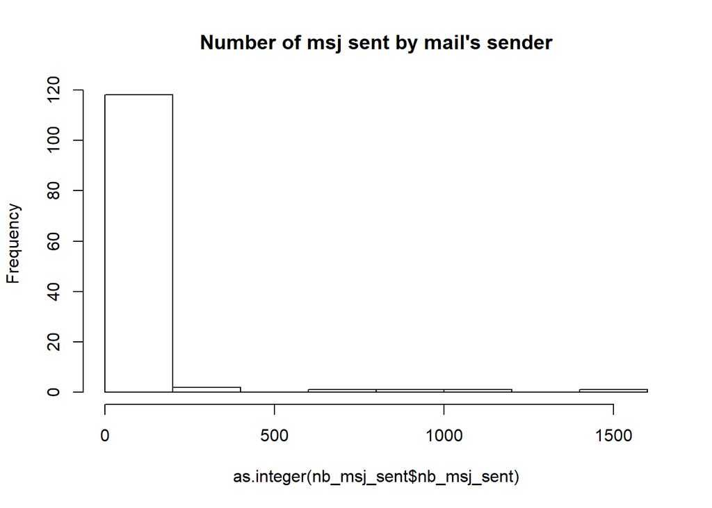

```r
# Binning the variables nb_msj_sent and wordcount
hist(as.integer(nb_msj_sent$nb_msj_sent), main = "Number of msj sent by mail's sender")
```

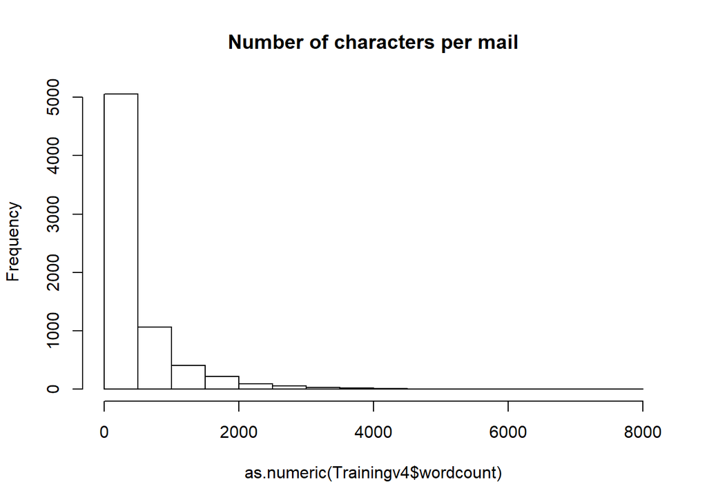

```r
hist(as.numeric(Trainingv4$wordcount), main = "Number of characters per mail")
```

```r
Trainingv4$nb_msj_sent <- cut(Trainingv4$nb_msj_sent, breaks = c(0, 500, 1100,
    1500), include.lowest = T)
levels(Trainingv4$nb_msj_sent) <- c("fewsent", "mediumsent", "largesent")
Trainingv4$wordcount <- cut(Trainingv4$wordcount, breaks = c(0, 77, 227, 584,
    7824), include.lowest = T)
levels(Trainingv4$wordcount) <- c("verysmallcnt", "smallcnt", "mediumcnt", "hugecnt")


## test dataset

# Communities
Testv4$Community_grp <- as.integer(Testv4$Community_grp)
Testv4$Community_grp <- paste0("community", numbers2words(Testv4$Community_grp))
# Weekday
Testv4$weekday = weekdays(as.Date(Testv4$Date))
# Weekend
Testv4$weekend = ifelse(Testv4$weekday %in% c("samedi", "dimanche"), "wkend",
    "nowkend")
# Year
Testv4$year <- year(as.Date(Testv4$Date))
Testv4$year <- recode(Testv4$year, `2009` = "dmilleneuf", `2010` = "dmilledix",
    `2011` = "dmilleonze", `2012` = "dmilledouze")
# Month
Testv4$months <- month(as.Date(Testv4$Date))

# Week (from 1 to 54)
Testv4$week <- week(as.Date(Testv4$Date))
Testv4$week <- paste0("wk", gsub(" ", "", numbers2words(Testv4$week)))
# Number of strings in the mail's body
Testv4$Content <- as.character(Testv4$Content)

Testv4$wordcount <- nchar(Testv4$Content)
# Number of messages sent by the sender of mail
nb_msj_sent_test <- sqldf("SELECT sender,COUNT(DISTINCT(Mail_ID)) as nb_msj_sent FROM Testv4 GROUP BY Sender")
Testv4 <- join(Testv4, nb_msj_sent_test, type = "left")
# Binning the variables nb_msj_sent and wordcount

Testv4$nb_msj_sent <- cut(Testv4$nb_msj_sent, breaks = c(0, 500, 1100, 1500),
    include.lowest = T)
levels(Testv4$nb_msj_sent) <- c("fewsent", "mediumsent", "largesent")
Testv4$wordcount <- cut(Testv4$wordcount, breaks = c(0, 77, 227, 584, 7824),
    include.lowest = T)
levels(Testv4$wordcount) <- c("verysmallcnt", "smallcnt", "mediumcnt", "hugecnt")
```

```r
# We clean the sender mail adress and extract his user name To do that we
# create a function
library(exploratory)
library(stringr)
clean_funct <- function(df) {
    sender_mail <- str_split(df$Sender, "@")
    df$sender_user <- gsub(",", ".", gsub("\\.", "", list_extract(sender_mail,
        1)))
    return(df)
}

# Apply the function
Trainingv5 <- clean_funct(Trainingv4)
Testv5 <- clean_funct(Testv4)
```

Lets visualize the final train and test data set.

```r
### drop usless columns
Trainingv5 <- Trainingv5[-7]
Testv5 <- Testv5[-6]
## export data sets into csv
write.csv(Trainingv5, "Trainingv5.csv", row.names = F, fileEncoding = "UTF-8")
write.csv(Testv5, "Testv5.csv", row.names = F, fileEncoding = "UTF-8")


writeLines("td, th { padding : 6px } th { background-color : brown ; color : white; border : 1px solid white; } td { color : brown ; border : 1px solid brown }",
    con = "mystyle.css")
knitr::kable(head(Trainingv5[1:3, ]), format = "html")
```

| Mail_ID | Sender | Date | Content | recipient | Community_grp | topic1 | topic2 | topic3 | weekday | weekend | year | week | wordcount | nb_msj_sent | sender_user |
| --- | --- | --- | --- | --- | --- | --- | --- | --- | --- | --- | --- | --- | --- | --- | --- |
| 1 | jake.sullivan@univ-tlse3.fr | 2012-09-12T04:00:00+00:00 | what a wonderful strong and moving statement by your boss please tell her how much sen mccain appreciated it me too | hillary.clinton@univ-tlse3.fr | communitytwo | topic8 | topic11 | topic16 | mercredi | nowkend | dmilledouze | wkthirtyseven | smallcnt | mediumsent | jakesullivan |
| 3 | cheryl.mills@univ-tlse3.fr | 2012-09-12T04:00:00+00:00 | thxto you and all my former colleagues im so terribly sorry our fsos stand on the front lines just as surely and devotedly as our soldiers do thinking of you and pat and everyone this morning am | b6@univ-tlse3.fr | communityone | topic24 | topic33 | topic2 | mercredi | nowkend | dmilledouze | wkthirtyseven | smallcnt | mediumsent | cherylmills |
| 3 | cheryl.mills@univ-tlse3.fr | 2012-09-12T04:00:00+00:00 | thxto you and all my former colleagues im so terribly sorry our fsos stand on the front lines just as surely and devotedly as our soldiers do thinking of you and pat and everyone this morning am | hillary.clinton@univ-tlse3.fr | communityone | topic19 | topic33 | topic38 | mercredi | nowkend | dmilledouze | wkthirtyseven | smallcnt | mediumsent | cherylmills |

```r
knitr::kable(head(Testv5[1:3, ]), format = "html")
```

| Mail_ID | Sender | Date | Content | Community_grp | topic1 | topic2 | topic3 | weekday | weekend | year | week | wordcount | nb_msj_sent | sender_user |
| --- | --- | --- | --- | --- | --- | --- | --- | --- | --- | --- | --- | --- | --- | --- |
| 1761 | strobe.talbott@univ-tlse3.fr | 2009-05-11T04:00:00+00:00 | hillary that was quite wonderful what you made possible this evening this evening was a lovely moment and ill long remember your line about pretty bunkers good luck in translating that into policy or … | communitythree | topic34 | topic3 | topic5 | lundi | nowkend | dmilleneuf | wknineteen | mediumcnt | fewsent | strobetalbott |
| 2376 | strobe.talbott@univ-tlse3.fr | 2009-07-16T04:00:00+00:00 | strobe i really appreciate your help on the speech along w all of your advice i just finished reading engaging india which is a marvelous read and sober reminder of how hard this work is you may have … | communitythree | topic34 | topic12 | topic30 | jeudi | nowkend | dmilleneuf | wktwentynine | mediumcnt | fewsent | strobetalbott |
| 2523 | strobe.talbott@univ-tlse3.fr | 2009-07-26T04:00:00+00:00 | fabulous couldnt have been better | communitythree | topic7 | topic23 | topic1 | dimanche | wkend | dmilleneuf | wkthirty | verysmallcnt | fewsent | strobetalbott |

We have created the train and test sets that we will use for modeling. Let’s move to python to do some predictions. ```